# GoogleHistoryQuest

Ariel

21 сентября 2016 г

## Цель исследования

Меня всегда интриговала концепция исследования себя, своей психики и способоностей. Неудивительно, что в конечном итоге я узнал о движении Quantified Self. Но всякие трекеры и программы для учета времени, пусть и предоставляют весьма точную информацию, но… скучны, быть может? Нет, конечно, знать сколько я сделал шагов это очень, очень здорово! Только тухло. Значит, нужно искать что-то иное. Например, можно поставить ManicTime и отслеживать всю свою жизнедеятельность за компьютером: фильмы, программирование, игры, книги, посещенные сайты. Ну, и на рабочий компьютер можно приложение поставить. И на ноут. И на телефон что-то придется подыскать. И на планш… ай, к черт! У меня же есть мой милый и любимый Google-аккаунт, средоточие информации обо мне, моя персональная точка G! Вот его и будем анализировать. Вернее, мои поисковые запросы.

## Материалы и методы

Найти саму историю достаточно [просто](http://just.google.it). Архив с поисковыми запросами в формате JSON попадает на GoogleDrive, оттуда его можно спокойно утащить к себе и радоваться. Собираем запросы в data.frame, определяемся с категориями поисковых запросов, помечаем их особым образом, саму поисковую фразу удаляем. Серьезно, это интимнее фотографий с медиума. Обработанный таким образом data.frame должен валяться где-то рядом в формате CSV.

Всего я буду анализировать 4 категории запросов:

- data - все так или иначе связанное с R - “r”, “ggplot2”, “data”
- films - обычное таймфажество, используемое как фон для принятия пищи или отхождения ко [сну](https://ru.wikipedia.org/wiki/Amazon_Women_in_the_Mood) - “фильм”,“видео”, “сезон”, “series”
- pr0n - эээ… *паблик рилейшнc зиро ньюс?* Да, верно! Самые свежие новости, новости **нулевого** дня о PR-индустрии!
- wh40k - `In the grim darkness of far future there is only war!` Да, да, Warhammer 40000. Он самый.

Вот такое вот summary у нашего датасета:

```
##       time               text
##  Min.   :2011-11-20   data :2819
##  1st Qu.:2014-11-05   films: 323
##  Median :2015-09-23   pr0n : 215
##  Mean   :2015-06-15   wh40k: 272
##  3rd Qu.:2016-03-09
##  Max.   :2016-08-19
```

Из библиотек понадобится лишь **dplyr**, **ggplot2**, **corrplot** и **factoextra**.

## Результаты и выводы

Тэкс. Что у нас тут?

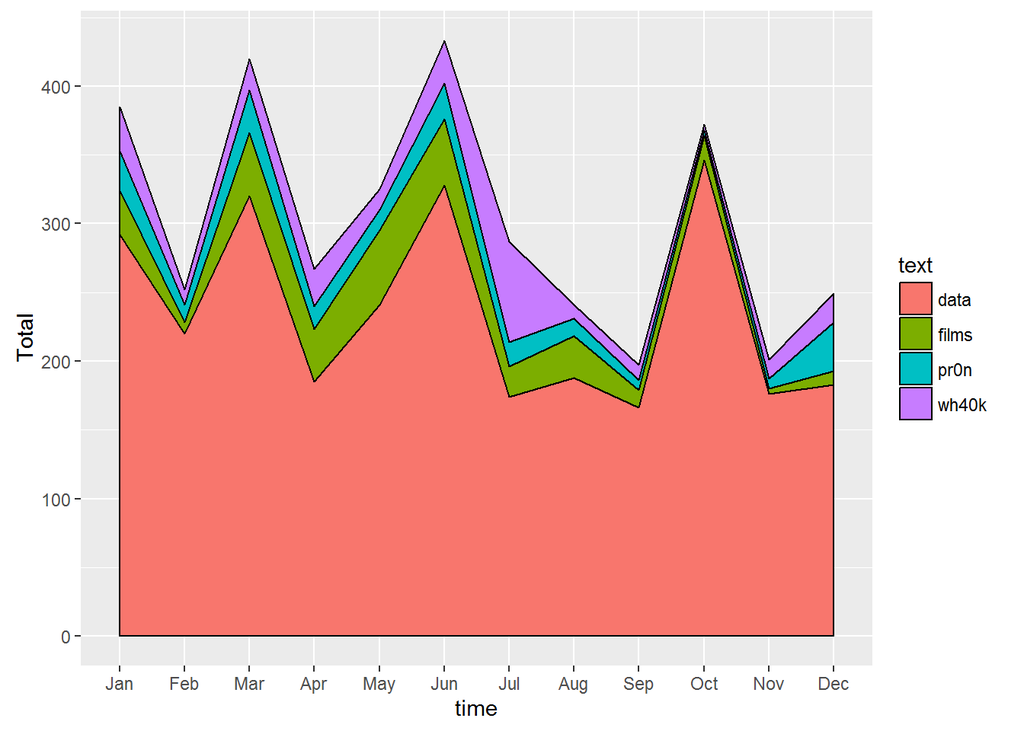

Хм. Наверное, не самые хорошие новости с точки зрения среднестатистического человека. Анализом данных я интересуюсь значительно больше, чем сериалами, pr0n’ом и - Святая Терра! - даже Вархаммером. Пики приходятся на март, июнь и октябрь. Март и октябрь - это время подготовки промежуточных отчетов по научным проектам, а вот июнь - йиху! - начало отпуска, когда я могу наконец-то заниматься тем, чем хочу сам! Не смотря на любопытный вид geom_area, все ж таки мне кажется не впихнуть преславутый ящик с усами было бы опрометчиво (иначе какая это научная статья?):

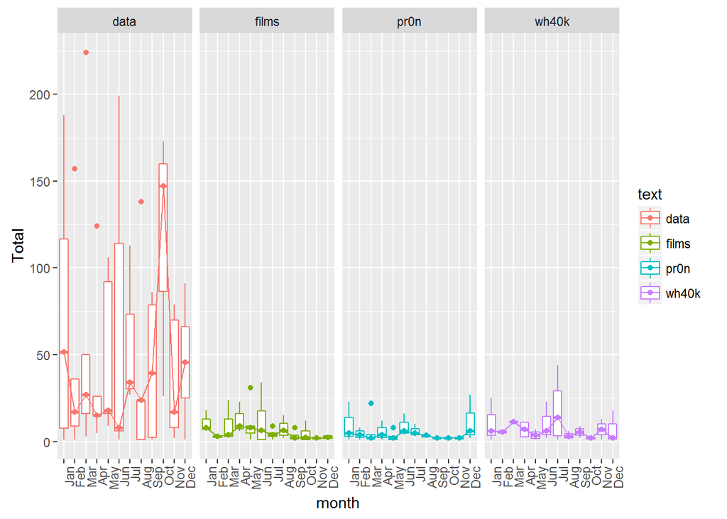

Ужас на самом деле - информативности никакой, да и читается наиотвратно. Но, что ж поделать - не пирожковые эти ваши диаграммы, и то хорошо. Попробуем что-нибудь прокоррелировать. Так как это почти настоящая научная статья, проверять на нормальность конечно же не будем, выберем метод, который дает наиболее подходящие нам результаты и, разумеется, опустим любые отсылки к р-значениям[^1].

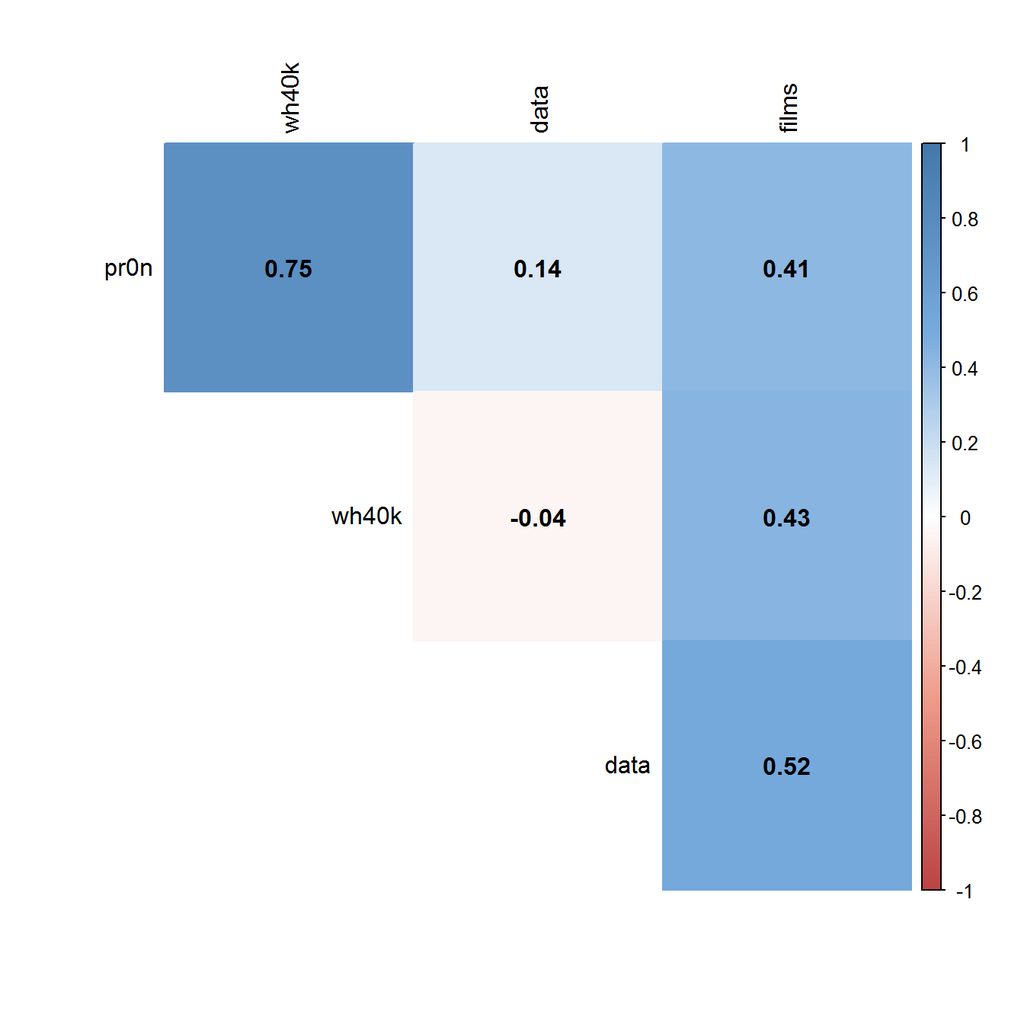

Дааа, грусть-печаль, мой интерес к данным никак не связан с Богом-Императором - коэффициент корреляции Спирмена составил всего -0.042. Зато под очередной голливудский шлак я, оказывается, вполне себе горазд и поанализировать что-нибудь. Исключительно лулзов ради посмотрим на еще один эриа-плот, на сей раз по дням:

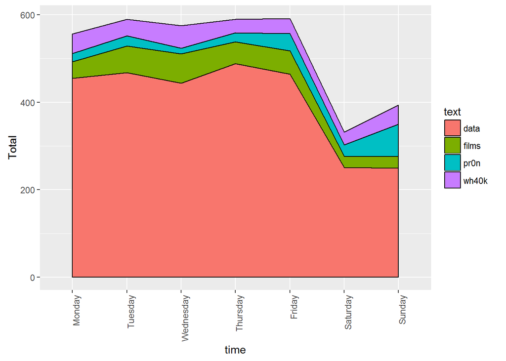

Да-да, data-запросы тухнут к выходным, на которых, что не удивительно, идет в гору pr0n. Ну, и напоследок небольшой пример того, как неряшливый корреляционный анализ может быть проиллюстрирован biplot’ом:

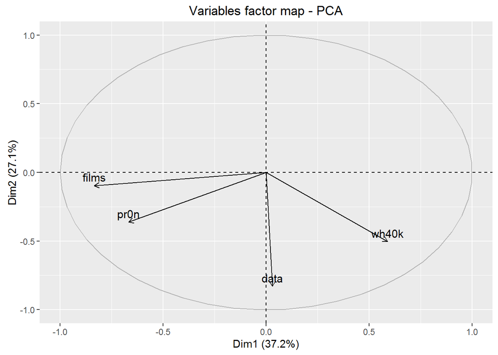

## Заключение

Всем спасибо за внимание! Искренне прошу прощения, если обидел кого-либо или потратил зря драгоценное время. Просто мне показалось, что немножко абсурда не помешает :)

[^1]: Да-да, это русская буква “эр”, а не какое-то это ваше заграничное “пи”!